# EQ12_TP1_Q1_analyse

Antonio Collante Caro (111 227 429)

Luc Grenier (902 201 689)

12 octobre, 2019

# 1 Météorologie et absences virtuelles

## 1.1 Charger les données Environnement Canada

Voici les 3 premières lignes des données d’environnement Canada (sans préparation):

Note: Erreur(warnings) pendant l’importation du fichier csv See spec(…) for full column specifications. Warning: 1 parsing failure. Raison: les erreurs ou warning sont dûes aux colonnes manquantes. Exemples: “2014-12-20 12:00”,“2014”,“12”,“20”,“12:00”

```
## # A tibble: 3 x 7
##   `Date/Time`         Year  Month Day   Time   `Temp (°C)` Weather
##   <dttm>              <chr> <chr> <chr> <time>       <dbl> <chr>
## 1 2014-01-01 00:00:00 2014  01    01    00:00        -21.6 <NA>
## 2 2014-01-01 01:00:00 2014  01    01    01:00        -21.6 Mostly Cloudy
## 3 2014-01-01 02:00:00 2014  01    01    02:00        -21.5 <NA>
```

## 1.2 Nettoyer les données d’Environnement Canada

Nombre d’observations dans les données d’Environnement Canada (avec summary) : 43824

Nombre d’observations dans les données d’Environnement Canada (avec nrow) : 43824

Nombre d’observations qui quontiennent des valeurs manquantes avant le traitement : 22073

Les trois permières lignes contenant des valeurs manquantes :

```
## # A tibble: 3 x 7
##   `Date/Time`         Year  Month Day   Time   `Temp (°C)` Weather
##   <dttm>              <chr> <chr> <chr> <time>       <dbl> <chr>
## 1 2014-01-01 00:00:00 2014  01    01    00:00        -21.6 <NA>
## 2 2014-01-01 02:00:00 2014  01    01    02:00        -21.5 <NA>
## 3 2014-01-01 03:00:00 2014  01    01    03:00        -21.3 <NA>
```

Nombre d’observations qui quontiennent des valeurs manquantes après le traitement : 0

Les trois premières lignes après le traitement des valeurs manquantes :

```
## # A tibble: 3 x 7
##   `Date/Time`         Year  Month Day   Time   `Temp (°C)` Weather
##   <dttm>              <chr> <chr> <chr> <time>       <dbl> <chr>
## 1 2014-01-01 00:00:00 2014  01    01    00:00        -21.6 Mostly Cloudy
## 2 2014-01-01 01:00:00 2014  01    01    01:00        -21.6 Mostly Cloudy
## 3 2014-01-01 02:00:00 2014  01    01    02:00        -21.5 Mostly Cloudy
```

Nombre de lignes restantes après le filtrage en fonction de l’heure (entre 8h et 19h) : 21912

Voici le code R qui permet de faire le traitement des données manquantes :

```r
   ## Replace the first row having NA value by the first !NA occurence
   weather_col = GLOBAL_$COLS[GLOBAL_$COL_WEATHER_POS]
   first_row  = GLOBAL_$FIRST_ROW

   if ( is.na(data_file_[first_row,weather_col]) )
   {
       first_non_NA_occurence = filter(data_file_, !is.na(data_file_$Weather))[first_row,weather_col]
       data_file_[first_row,weather_col] = first_non_NA_occurence
   }

   ## Replace the NA's values in the tibble by the previous !NA value
   data_file_  = fill(data_file_,weather_col)
```

## 1.3 Charger les données de connexion des employés au serveur

Voici les 3 premières lignes des données du fichier de connexion des employés au serveur :

```
## # A tibble: 3 x 5
##   `Date/Time`         log_emp1 log_emp2 log_emp3 weekend
##   <dttm>              <lgl>    <lgl>    <lgl>    <lgl>
## 1 2014-01-01 08:00:00 FALSE    FALSE    TRUE     FALSE
## 2 2014-01-01 09:00:00 TRUE     FALSE    FALSE    FALSE
## 3 2014-01-01 10:00:00 FALSE    FALSE    FALSE    FALSE
```

## 1.4 Nettoyer les données horaire des employés

Voici les 3 premières lignes des données du fichier de connexion des employés au serveur suite à la transformation :

```
## # A tibble: 3 x 7
##   employe_no `Date/Time`         Year  Month Day    Hour weekend
##        <int> <dttm>              <chr> <chr> <chr> <int> <lgl>
## 1          1 2014-01-01 09:00:00 2014  01    01        9 FALSE
## 2          1 2014-01-01 18:00:00 2014  01    01       18 FALSE
## 3          1 2014-01-02 09:00:00 2014  01    02        9 FALSE
```

## 1.5 Identifier les “belles” heures, combiner la météo et les connexions

Nombre d’observation dans les tables avant la jointure: employés 19524 et météo 21912

Nombre d’observation de la table jointe des employés et de la météo: 19524

Nombre d’observations qui quontiennent des valeurs manquantes après la jointure : 0

Voici les 5 premières lignes de la table des données de météo après transformation :

```
## # A tibble: 5 x 9
##   `Date/Time`         Year  Month Day   Time  `Temp (°C)` Weather  Hour
##   <dttm>              <chr> <chr> <chr> <tim>       <dbl> <chr>   <int>
## 1 2014-01-01 08:00:00 2014  01    01    08:00       -22.9 Ice Cr~     8
## 2 2014-01-01 09:00:00 2014  01    01    09:00       -22.1 Ice Cr~     9
## 3 2014-01-01 10:00:00 2014  01    01    10:00       -20.3 Clear      10
## 4 2014-01-01 11:00:00 2014  01    01    11:00       -19.6 Clear      11
## 5 2014-01-01 12:00:00 2014  01    01    12:00       -18.8 Clear      12
## # ... with 1 more variable: is_bad_weather <lgl>
```

Voici les 5 premières lignes de la table jointe des données de météo et des données de connexions des employés :

```
## # A tibble: 5 x 12
##   employe_no `Date/Time.x`       Year  Month Day    Hour weekend
##        <int> <dttm>              <chr> <chr> <chr> <int> <lgl>
## 1          1 2014-01-01 09:00:00 2014  01    01        9 FALSE
## 2          1 2014-01-01 18:00:00 2014  01    01       18 FALSE
## 3          1 2014-01-02 09:00:00 2014  01    02        9 FALSE
## 4          1 2014-01-02 13:00:00 2014  01    02       13 FALSE
## 5          1 2014-01-02 18:00:00 2014  01    02       18 FALSE
## # ... with 5 more variables: `Date/Time.y` <dttm>, Time <time>, `Temp
## #   (°C)` <dbl>, Weather <chr>, is_bad_weather <lgl>
```

## 1.6 Est-ce que la température a un impact?

La figure 1 présente le nombre de connexions au serveur de chacun des trois employés pour la période de mai à septembre. Cette période a été évaluée comme étant « estival » où la température est plus clémente. Ce graphique nous permet d’analyser si certains employés sont plus susceptibles de ne pas travailler en présence d’une belle température (température de plus de 20 degrés, non pluvieuse et non brumeuse). À noter que les zones plus pâles (transparence) des couleurs indiquent que l’employé s’est connecté le weekend.

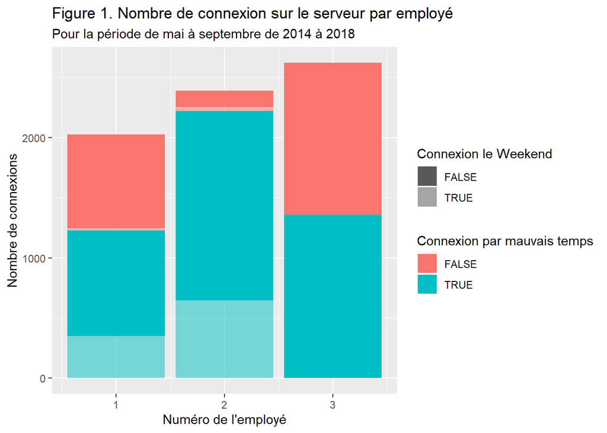

En analysant le premier employé, nous pouvons constater que celui-ci travaille légèrement plus par mauvais temps que par beau temps. En effet, cet employé se connecte 60% du temps lorsque la température est moins clémente. De plus, il se connecte aussi le weekend principalement lorsque la température n’est pas au rendez-vous. Toutefois, pour cette période, cet employé semble avoir un nombre de connexions inférieur aux autres.

En ce qui concerne le deuxième employé, nous pouvons réaliser que celui-ci semble plus profiter du beau temps. En effet, celui-ci se connecte 93% du temps en période de mauvais temps. Toutefois, cet employé semble se reprendre les weekends. Parmi les 3 employés, il est celui qui se connecte le plus souvent le weekend par mauvais temps. Au total des connexions pour cette période, il s’est connecté davantage que le premier, mais moins que le troisième.

En analysant le troisième employé, nous pouvons constater que celui-ci travaille pratiquement à proportion égale beau temps et mauvais temps. Toutefois, il semble avoir pris une routine de travailler que la semaine et non les weekends. Il est à noter qu’il est l’employé qui s’est connecté le plus durant cette période.

En somme, le premier employé et principalement le deuxième employé semblent en effet se connecter au serveur selon la température extérieure. Toutefois, ces derniers semblent se rattraper les weekends. De plus, il est à noter que dans l’ensemble des années, le deuxième employé est celui qui s’est connecté le plus (8063 connexions, contre 5242 pour le premier et 6219 pour le troisième. Donc, malgré le nombre de connexions moindre durant l’été pour le deuxième employé, il se connecte davantage le reste de l’année. Ainsi, la température semble avoir un impact sur la présence au travail de deux des employés durant l’été, mais cet impact ne se reflète pas sur l’ensemble du travail annuel de ces employés.